# STAT 302 Fall 2025 - Final Project

Johnny Kress

12-12-25

The assignment should be completed in an [R Markdown](https://rmarkdown.rstudio.com) document. Submit the assignment electronically on Gradescope by December 12, 2025, at 11:59 PM as a PDF file. No late submission will accepted.

Each answer has to be based on `R` code that shows how the result was obtained. `R` code has to answer the question or solve the task.

NOTE: :

The total number of points of this assignment is 50 points.

Good luck!

# 1 K means clustering

In this project, you will implement an unsupervised learning technique called **k-means clustering**. This method is used to partition a dataset into $k$ distinct clusters based on the similarity of the data points. The goal of k-means is to minimize the variance within each cluster, so that points within the same cluster are as similar as possible.

While there is a built-in function in base R that can perform k-means clustering, you are not allowed to use it in this project. Instead, you will manually implement the algorithm from scratch.

Your task is to replicate this process and implement the algorithm manually using base `R` functions, without relying on any built-in `R` functions (such as the `knn()` function) and without relying on any specialized clustering libraries.

Consider :

```r
taylor_album_songs <- read.csv('https://raw.githubusercontent.com/rfordatascience/tidytuesday/master/data/2023/2023-10-17/taylor_album_songs.csv')
songs_reduced <- taylor_album_songs[,c("track_number", "energy", "valence")]
songs_reduced_final <- songs_reduced[rowSums(is.na(songs_reduced))==0,]
```

Or use the data set `Mall_Customers.csv` uploaded on Canvas in the folder named `final project`.

In order to simplify your task, if you are working with the `mall_customers` data set, consider only the quantitative variables. If you are working with the Taylor Swift songs, you will work on with energy and valence since track_number is a label rather than a meaningful variable.

1. In order to start exploring the dataset, use base `R` or `ggplot` to create data visualizations (at least 2).

```r
library(ggplot2)
mydata <- songs_reduced_final[, c("energy", "valence")]
```

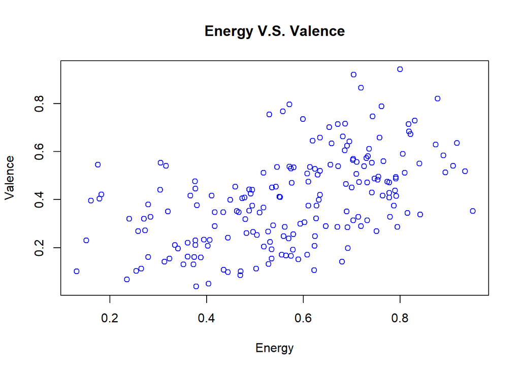

```r
plot(mydata$energy, mydata$valence, col="blue", xlab = "Energy", ylab = "Valence", main = "Energy V.S. Valence")
```

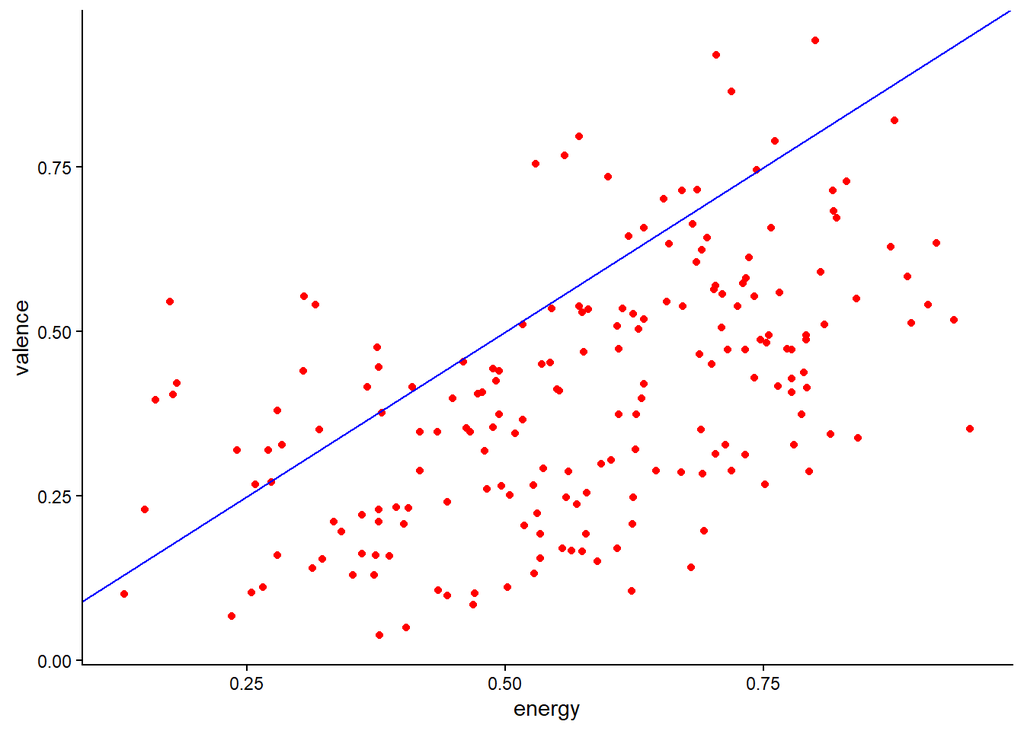

```r
ggplot(data = mydata <- songs_reduced_final[, c("energy", "valence")]
, mapping = aes(x = energy, y = valence)) +
geom_point(col = "red") +
geom_abline(col = "blue")+
  theme_classic()
```

There seems to be a positive linear trend between energy and valence.

2. Randomly choose any three points from the dataset which will be your initial centroids. These will define the centers of the first initial three clusters. This means that you are defining $k=3$ clusters.

```r
set.seed(123)
k <- 3
mydata <- songs_reduced_final[, c("energy", "valence")]
incentroids <- mydata[sample(nrow(mydata), k, replace = F),]

incentroids
```

```
##     energy valence
## 159  0.361   0.221
## 179  0.279   0.160
## 14   0.751   0.268
```

3. Measure the distance between all the points in the dataset and each of the three initial clusters. Assign the points to the nearest cluster. Do this in the most efficient way.

```r
#creating as a function since I need to use it so many time in the rest of the code.
assign_clusters <- function(datax, centroidsx){
distances <- sqrt(outer(datax[,1], centroidsx[,1], "-")^2 +
                  outer(datax[,2], centroidsx[,2], "-")^2)

clusters <- max.col(-distances)
return(clusters)
}
kclusters <- assign_clusters(mydata, incentroids)
kclusters
```

```
##   [1] 1 3 1 3 1 3 3 3 3 3 3 3 1 3 3 3 3 3 3 1 3 3 3 1 3 3 3 3 3 1 1 1 1 3 3 1 3
##  [38] 1 3 1 3 3 3 3 3 1 3 3 1 3 3 3 3 1 3 3 3 3 3 3 3 3 1 3 3 3 3 1 3 1 3 3 3 1
##  [75] 1 3 3 2 1 3 1 3 3 3 3 1 3 1 3 3 3 3 3 3 3 3 3 3 1 3 1 3 1 3 3 3 3 1 2 3 3
## [112] 3 3 3 3 1 3 1 2 1 3 3 3 3 1 3 3 3 3 3 1 1 3 1 3 1 1 1 3 3 1 2 1 1 3 1 1 1
## [149] 3 2 1 1 1 2 3 1 1 1 1 3 1 1 1 3 1 3 3 3 1 3 1 1 2 3 2 1 1 1 2 3 2 3 2 2 3
## [186] 2 1 3 1 3 1
```

4. After assigning all points to the closest centroid, recalculate the centroids. This is achieved by computing the mean of all the variables of the points assigned to each cluster. This will give you the new centroids.

```r
#Again creating as function since I need to do this a lot
recalcentroids <- function(X, rcentroids, rclusters) {
  for (i in 1:nrow(rcentroids)) {
    checkzero <- X[rclusters == i, ]
    if(nrow(checkzero) > 0){
    rcentroids[i,] <-
      colMeans(X[which(rclusters == i),])
    } else{
      recentroids[i,] <- recentroids[i,]
    }
  }
  return(rcentroids)
}
recentroids <- recalcentroids(mydata, incentroids, kclusters)
recentroids
```

```
##        energy   valence
## 159 0.4173846 0.3017769
## 179 0.2695385 0.1500846
## 14  0.6999469 0.4866991
```

5. Repeat the process of assigning points to clusters and updating the centroids until the centroids no longer change.

```r
set.seed(123)
difference <- 100
tol <- 1e-6
iters <- 0
centroids <- recentroids

while(difference > tol && iters < 10000){



kclusters <- assign_clusters(mydata, centroids)
#function from before assigning clusters

icentroids <- recalcentroids(mydata, centroids, kclusters)
#function from before recalculating centroids


difference <- sum(abs(icentroids - centroids), na.rm = T)
if(iters == 0) difference <- 100
iters <- iters + 1
centroids <- icentroids
}

centroids
```

```
##        energy   valence
## 159 0.5872388 0.3033881
## 179 0.3311400 0.2585520
## 14  0.7273784 0.5852568
```

6. Calculate the Within-Cluster-Sum of Squared Errors (WSS) for different values of k (including the $k=3$). The WSS is given by:

$$\text{WSS} = \sum_{k=1}^{K} \sum_{i=1}^{n_k} \left( \mathbf{x}_i^{(k)} -
\boldsymbol{\mu}_k \right)^\top \left( \mathbf{x}_i^{(k)} -
\boldsymbol{\mu}_k \right)$$

```r
#WSS function, Again i felt it was reasonable to make a function for how much it will be used
WSS_total <- function(X, clusters, K) {
  X <- as.matrix(X)
  WSS <- 0
  for(i in 1:K){
    clusterk <- X[which(clusters == i),]
    muk <- colMeans(clusterk)
    kwss <- sum(sweep(clusterk, 2, muk, "-")^2)
    WSS <- WSS + kwss
  }
  return(WSS)
}
```

```r
#Felt a function was reasonable since I need to use it for the data sets after this
set.seed(123)
k_means <- function(mydata1){
set.seed(123)
 WSS <- numeric(10)
for(c in 1:10){

difference <- 100
iters <- 0
tol <- 0.000001

centroids <- mydata1[sample(nrow(mydata1), c, replace = F),]

while(difference > tol && iters < 10000) {

kclusters <- assign_clusters(mydata1, centroids)


newcentroids <- recalcentroids(mydata1, centroids, kclusters)
if(any(is.na(newcentroids))) {
  for (i in 1:c) {
      newcentroids[i, ] <- centroids[i, ]

  }
}

 difference <- sum(abs(newcentroids - centroids))
 iters <- iters +1
 centroids <- newcentroids
}

WSS[c] <- WSS_total(mydata1, kclusters, c)

}

return(WSS)

}
WSS <- k_means(mydata)
WSS
```

```
##  [1] 13.285751  5.976887  4.419216  3.497047  3.028533  2.387716  1.847129
##  [8]  1.670301  1.482259  1.333623
```

7. Using either base R or ggplot2, plot WSS-versus-k. Choose the k for which the rate of decrease of WSS sharply changes. In the plot, this is visible as an elbow.

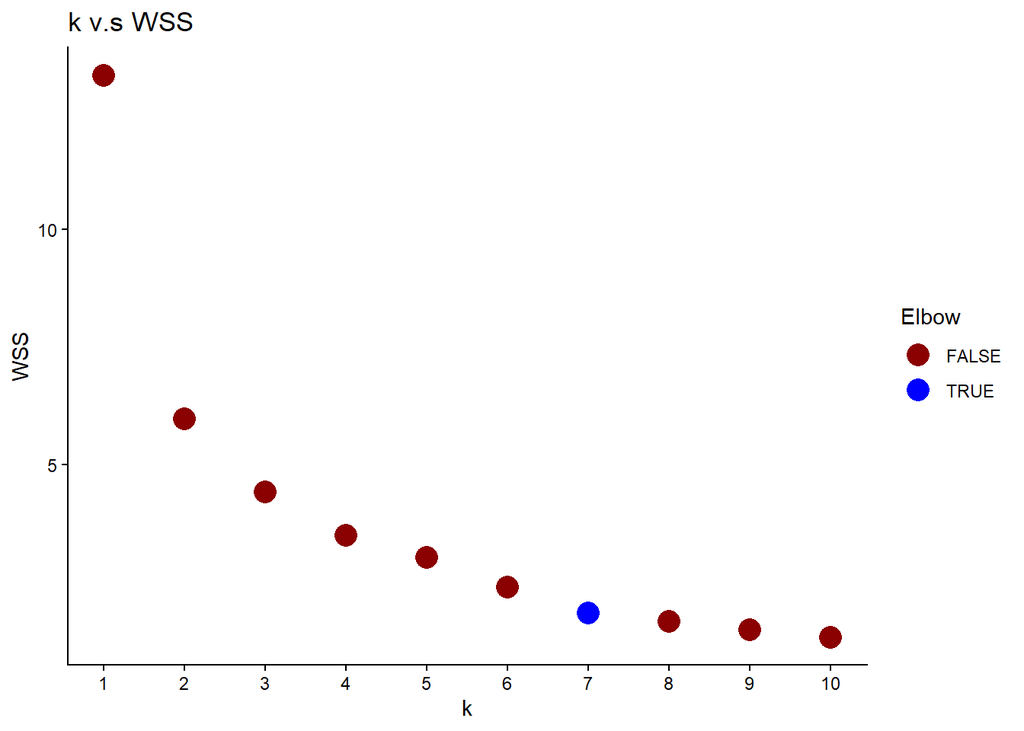

```r
wssdf <- data.frame(k = 1:10,  WSS)

ggplot(data = wssdf, mapping = aes(x = k, y= WSS)) +
  geom_point(aes(color = k == 7), size = 5) +
  scale_color_manual(values = c("FALSE" = "darkred", "TRUE" = "blue")) +
  theme_classic()+
  labs(title = "k v.s WSS", x = "k", y = "WSS", color = "Elbow") +
  scale_x_continuous(breaks=1:20)
```

8. Based on this clustering, add a variable called `cluster` to the data set. Use the variables in the data set (both the ones used for clustering and the ones not used for clustering) to visually describe the clusters. Explain what differences you observe.

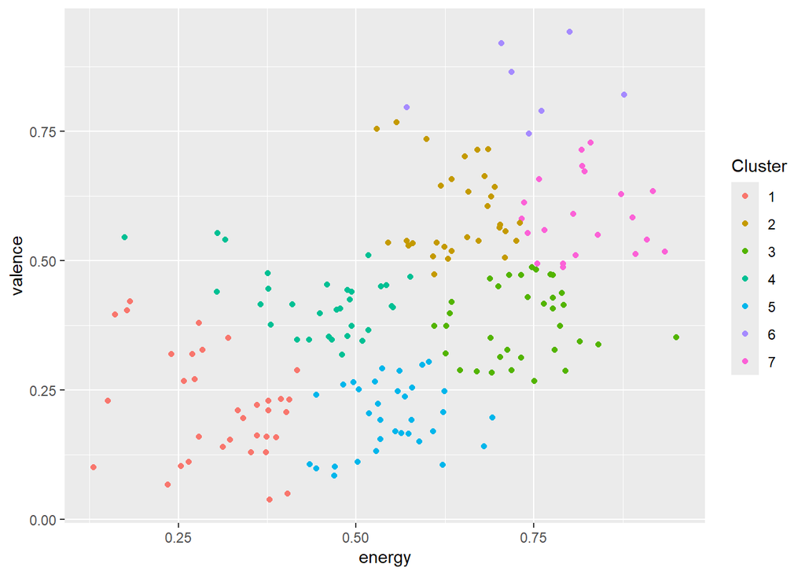

```r
difference <- 100
iters <- 0
tol <- 0.000001

centroids <- mydata[sample(nrow(mydata), 7, replace = F),]

while(difference > tol && iters < 10000) {

elbow <- assign_clusters(mydata, centroids)


newcentroids <- recalcentroids(mydata, centroids, elbow)
if(any(is.na(newcentroids))) {
  for (i in 1:c) {
      newcentroids[i, ] <- centroids[i, ]

  }
}

 difference <- sum(abs(newcentroids - centroids))
 iters <- iters +1
 centroids <- newcentroids
}

mydatacluster <- data.frame(mydata, "cluster" = elbow)

ggplot(mydatacluster, mapping = aes(x = energy, y = valence, color = factor(cluster)))+
geom_point()+
labs(color = "Cluster")
```

9. K-means clustering performs well in some situations and poorly in others. In general, it works best when data points form well-separated clusters and struggles when clusters are overlapping or absent.

```r
library(MASS)
set.seed(123)

n <- nrow(mydata)
mu <- rbind(c(0,0), c(5,5), c(10,2))
sigma <- matrix(c(1, 0, 0, 1), 2, 2)
dataclear <- rbind(
  mvrnorm(round(n/3), mu[1,], sigma),
  mvrnorm(round(n/3), mu[2,], sigma),
  mvrnorm(round(n/3), mu[3,], sigma)
)


dfclear <- data.frame(x = dataclear[,1], y = dataclear[,2], cluster = rep(1:3, each = round(n/3)))

muweak <- rbind(c(0,0), c(2,2), c(0,3))
Sigma_weak <- matrix(c(2, 1, 1, 2), 2, 2)

data_weak <- rbind(
  mvrnorm(round(n/3), muweak[1,], Sigma_weak),
  mvrnorm(round(n/3), muweak[2,], Sigma_weak),
  mvrnorm(round(n/3), muweak[3,], Sigma_weak)
)
dfweak <- data.frame(x = data_weak[,1], y = data_weak[,2], cluster = rep(1:3, each = round(n/3)))

munone <- c(0, 0)
sigmanone <- matrix(c(3, 1, 1, 3), 2, 2)
datanone <- mvrnorm(n, munone, sigmanone)
dfnone <- data.frame(x = datanone[,1], y = datanone[,2],  cluster = rep(1, n))
```

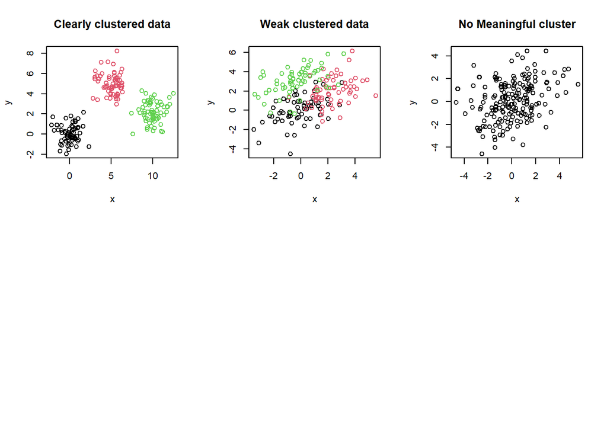

```r
par(mfrow = c(2, 3))

plot(dfclear$x, dfclear$y,
     col = dfclear$cluster,
     main = "Clearly clustered data",
     xlab = "x",
     ylab = "y")

plot(dfweak$x, dfweak$y,
     col = dfweak$cluster,
     main = "Weak clustered data",
     xlab = "x",
     ylab = "y")

plot(dfnone$x, dfnone$y,
     col = dfnone$cluster,
     main = "No Meaningful cluster",
     xlab = "x",
     ylab = "y" )
```

```r
set.seed(123)
dfclearnew <- dfclear[,-3]
dfweaknew <- dfweak[,-3]
dfnonenew <- dfnone[,-3]
wssclear <- k_means(dfclearnew)
wssweak <-k_means(dfweaknew)
wssnone <- k_means(dfnonenew)
```

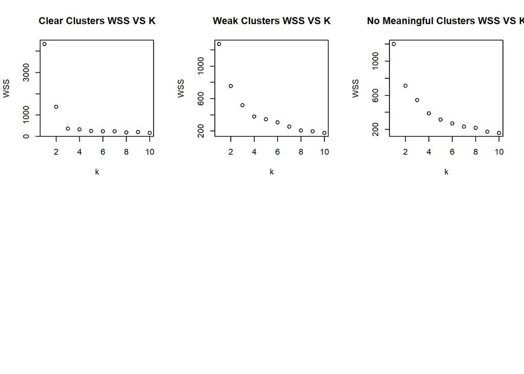

```r
par(mfrow = c(2,3))
plot(wssclear, main = "Clear Clusters WSS VS K", xlab = "k" , ylab = "WSS")
plot(wssweak, main = "Weak Clusters WSS VS K", xlab = "k" , ylab = "WSS")
plot(wssnone, main = "No Meaningful Clusters WSS VS K", xlab = "k" , ylab = "WSS")
```

Clear clusters has an extreme drop in WSS as k increases from 1:3. Weak clusters is more gradually decreasing and no meaningful clusters is even more gradual than weak clusters. Best K for clear clusters looks like 3, best k for weak clusters looks like 6, and best k for weak clusters is 7.

```r
clearstability <- matrix(0, nrow(dfclearnew), nrow(dfclearnew))
seeds <- sample(1:1000, 10)
for(i in seeds){
  set.seed(i)
difference <- 100
iters <- 0
tol <- 0.000001

centroids <- dfclearnew[sample(nrow(dfclearnew), 3, replace = F),]

while(difference > tol && iters < 10000) {

kclusters <- assign_clusters(dfclearnew, centroids)

newcentroids <- recalcentroids(dfclearnew, centroids, kclusters)
if(any(is.na(newcentroids))) {
  for (b in 1:nrow(newcentroids)) {
      newcentroids[b, ] <- centroids[b, ]

  }
}

 difference <- sum(abs(newcentroids - centroids))
 iters <- iters +1
 centroids <- newcentroids
}
dfclearclusters <- cbind(dfclearnew, kclusters)
#check pairs
for (l in 1:length(kclusters - 1)) {
  for(j in (l+1):length(kclusters)){
    if (!is.na(kclusters[l]) && !is.na(kclusters[j]) && kclusters[l] == kclusters[j]) {
      clearstability[l,j] = clearstability[l,j] + 1
    }
  }

}

}
clearstabilityp <- clearstability / 10
```

```r
weakstability <- matrix(0, nrow(dfweaknew), nrow(dfweaknew))
seeds <- sample(1:1000, 10)
for(i in seeds){
  set.seed(i)
difference <- 100
iters <- 0
tol <- 0.000001

centroids <- dfweaknew[sample(nrow(dfweaknew), 6, replace = F),]

while(difference > tol && iters < 10000) {

kclusters <- assign_clusters(dfweaknew, centroids)

newcentroids <- recalcentroids(dfweaknew, centroids, kclusters)
if(any(is.na(newcentroids))) {
  for (b in 1:nrow(newcentroids)) {
      newcentroids[b, ] <- centroids[b, ]

  }
}

 difference <- sum(abs(newcentroids - centroids))
 iters <- iters +1
 centroids <- newcentroids
}

#check pairs
for (l in 1:length(kclusters - 1)) {
  for(j in (l+1):length(kclusters)){
    if (!is.na(kclusters[l]) && !is.na(kclusters[j]) && kclusters[l] == kclusters[j]) {
      weakstability[l,j] = weakstability[l,j] + 1
    }
  }

}

}
weakstabilityp <- weakstability /10
```

```r
nonestability <- matrix(0, nrow(dfnonenew), nrow(dfnonenew))
seeds <- sample(1:1000, 10)
for(i in seeds){
  set.seed(i)
difference <- 100
iters <- 0
tol <- 0.000001

centroids <- dfnonenew[sample(nrow(dfnonenew), 7, replace = F),]

while(difference > tol && iters < 10000) {

kclusters <- assign_clusters(dfnonenew, centroids)

newcentroids <- recalcentroids(dfnonenew, centroids, kclusters)
if(any(is.na(newcentroids))) {
  for (b in 1:nrow(newcentroids)) {
      newcentroids[b, ] <- centroids[b, ]

  }
}

 difference <- sum(abs(newcentroids - centroids))
 iters <- iters +1
 centroids <- newcentroids
}
#check pairs
for (l in 1:length(kclusters - 1)) {
  for(j in (l+1):length(kclusters)){
    if (!is.na(kclusters[l]) && !is.na(kclusters[j]) && kclusters[l] == kclusters[j]) {
      nonestability[l,j] = nonestability[l,j] + 1
    }
  }

}

}
nonestabilityp <- nonestability / 10
```

```r
cat("Clear Clusters Stability", sum(clearstabilityp) / (nrow(clearstabilityp) * ncol(clearstabilityp)), "\n")
```

```
## Clear Clusters Stability 0.1640896
```

```r
cat("Weak Clusters Stability", sum(weakstabilityp) / (nrow(weakstabilityp) * ncol(weakstabilityp)), "\n")
```

```
## Weak Clusters Stability 0.08834093
```

```r
cat("None meaningful Clusters Stability = ", sum(nonestabilityp) / (nrow(weakstabilityp) * ncol(weakstabilityp )), "\n")
```

```
## None meaningful Clusters Stability =  0.0777398
```

Clear Clusters had much higher stability than weak and none meaningful clusters. Weak had a little bit more stability than none meaningful clusters but not by much.